# Praktikum 3

## Data 2

```r
# Input Data Latihan 2
dt2 <- data.frame(
  Year = 1975:2014,
  Sales = c(11.7, 12.0, 12.3, 12.8, 13.1, 13.6, 13.9, 14.4, 14.7, 15.3,
            15.5, 15.8, 16.1, 16.6, 16.9, 16.7, 16.9, 17.4, 17.6, 17.9,
            18.0, 17.9, 18.0, 18.2, 18.2, 18.3, 18.6, 19.2, 19.3, 19.5,
            19.2, 19.3, 19.5, 20.0, 20.0, 19.9, 19.8, 19.9, 20.2, 21.0),
  Advertising = c(9.4, 9.6, 10.0, 10.4, 10.8, 10.9, 11.7, 12.2, 12.5, 12.9,
                  13.0, 13.2, 13.8, 14.2, 14.6, 14.4, 15.0, 15.4, 15.7, 15.9,
                  15.9, 16.0, 16.3, 16.2, 16.8, 17.3, 17.6, 18.1, 18.3, 18.5,
                  18.7, 18.9, 19.2, 20.0, 20.0, 20.3, 20.4, 21.0, 21.5, 22.1)
)

# Pembagian Train (30 periode awal) dan Test (10 periode akhir)
train2 <- dt2[1:30, ]
test2  <- dt2[31:40, ]
```

```r
koyck2 <- koyckDlm(x = train2$Advertising, y = train2$Sales)
summary(koyck2)
```

```
##
## Call:
## "Y ~ (Intercept) + Y.1 + X.t"
##
## Residuals:
##       Min        1Q    Median        3Q       Max
## -0.265890 -0.120691 -0.005297  0.107270  0.267226
##
## Coefficients:
##             Estimate Std. Error t value Pr(>|t|)
## (Intercept)  1.61369    0.38958   4.142 0.000322 ***
## Y.1          0.74280    0.09797   7.582 4.77e-08 ***
## X.t          0.19436    0.08585   2.264 0.032152 *
## ---
## Signif. codes:  0 '***' 0.001 '**' 0.01 '*' 0.05 '.' 0.1 ' ' 1
##
## Residual standard error: 0.156 on 26 degrees of freedom
## Multiple R-Squared: 0.9954,  Adjusted R-squared: 0.995
## Wald test:  2796 on 2 and 26 DF,  p-value: < 2.2e-16
##
## Diagnostic tests:
## NULL
##
##                             alpha      beta       phi
## Geometric coefficients:  6.274186 0.1943614 0.7428042
```

```r
fore.koyck2 <- forecast(model = koyck2, x = test2$Advertising, h = 10)
mape.koyck2 <- MAPE(fore.koyck2$forecasts, test2$Sales)
```

```r
# Cari Lag Optimum menggunakan perulangan AIC
aic_val2 <- vector()
for(q in 1:5) {
  fit <- dlm(x = train2$Advertising, y = train2$Sales, q = q)
  aic_val2[q] <- AIC(fit$model)
}

# Ambil lag dengan nilai AIC terkecil
q_best2 <- which.min(aic_val2)

# Pemodelan DLM Optimum
dlm2 <- dlm(x = train2$Advertising, y = train2$Sales, q = q_best2)
summary(dlm2)
```

```
##
## Call:
## lm(formula = model.formula, data = design)
##
## Residuals:
##      Min       1Q   Median       3Q      Max
## -0.32393 -0.14336 -0.02437  0.16772  0.39208
##
## Coefficients:
##             Estimate Std. Error t value Pr(>|t|)
## (Intercept)  6.00171    0.45344  13.236 1.03e-10 ***
## x.t          0.08551    0.20828   0.411    0.686
## x.1          0.33373    0.26137   1.277    0.218
## x.2          0.09227    0.26072   0.354    0.728
## x.3          0.17180    0.26536   0.647    0.526
## x.4         -0.05009    0.26543  -0.189    0.852
## x.5          0.12649    0.20696   0.611    0.549
## ---
## Signif. codes:  0 '***' 0.001 '**' 0.01 '*' 0.05 '.' 0.1 ' ' 1
##
## Residual standard error: 0.2253 on 18 degrees of freedom
## Multiple R-squared:  0.9867, Adjusted R-squared:  0.9822
## F-statistic:   222 on 6 and 18 DF,  p-value: 7.15e-16
##
## AIC and BIC values for the model:
##        AIC      BIC
## 1 4.215765 13.96677
```

```r
fore.dlm2 <- forecast(model = dlm2, x = test2$Advertising, h = 10)
mape.dlm2 <- MAPE(fore.dlm2$forecasts, test2$Sales)
```

```r
# Pemodelan ARDL (p=1, q=1) menggunakan formula
ardl2 <- ardlDlm(formula = Sales ~ Advertising, data = train2, p = 1, q = 1)
summary(ardl2)
```

```
##
## Time series regression with "ts" data:
## Start = 2, End = 30
##
## Call:
## dynlm(formula = as.formula(model.text), data = data)
##
## Residuals:
##       Min        1Q    Median        3Q       Max
## -0.229277 -0.127437  0.009143  0.109228  0.259132
##
## Coefficients:
##               Estimate Std. Error t value Pr(>|t|)
## (Intercept)    1.55786    0.44353   3.512  0.00171 **
## Advertising.t  0.29110    0.13707   2.124  0.04376 *
## Advertising.1 -0.09584    0.16067  -0.596  0.55621
## Sales.1        0.74360    0.09964   7.463 8.14e-08 ***
## ---
## Signif. codes:  0 '***' 0.001 '**' 0.01 '*' 0.05 '.' 0.1 ' ' 1
##
## Residual standard error: 0.1576 on 25 degrees of freedom
## Multiple R-squared:  0.9955, Adjusted R-squared:  0.9949
## F-statistic:  1830 on 3 and 25 DF,  p-value: < 2.2e-16
```

```r
# Peramalan dan perhitungan MAPE
fore.ardl2 <- forecast(model = ardl2, x = test2$Advertising, h = 10)
mape.ardl2 <- MAPE(fore.ardl2$forecasts, test2$Sales)
```

```r
eval2 <- data.frame(
  Model = c("Koyck", paste("DLM (q =", q_best2, ")"), "ARDL (p=1, q=1)"),
  MAPE = c(mape.koyck2, mape.dlm2, mape.ardl2)
)
eval2
```

```
##             Model       MAPE
## 1           Koyck 0.04712769
## 2    DLM (q = 5 ) 0.04981800
## 3 ARDL (p=1, q=1) 0.04848320
```

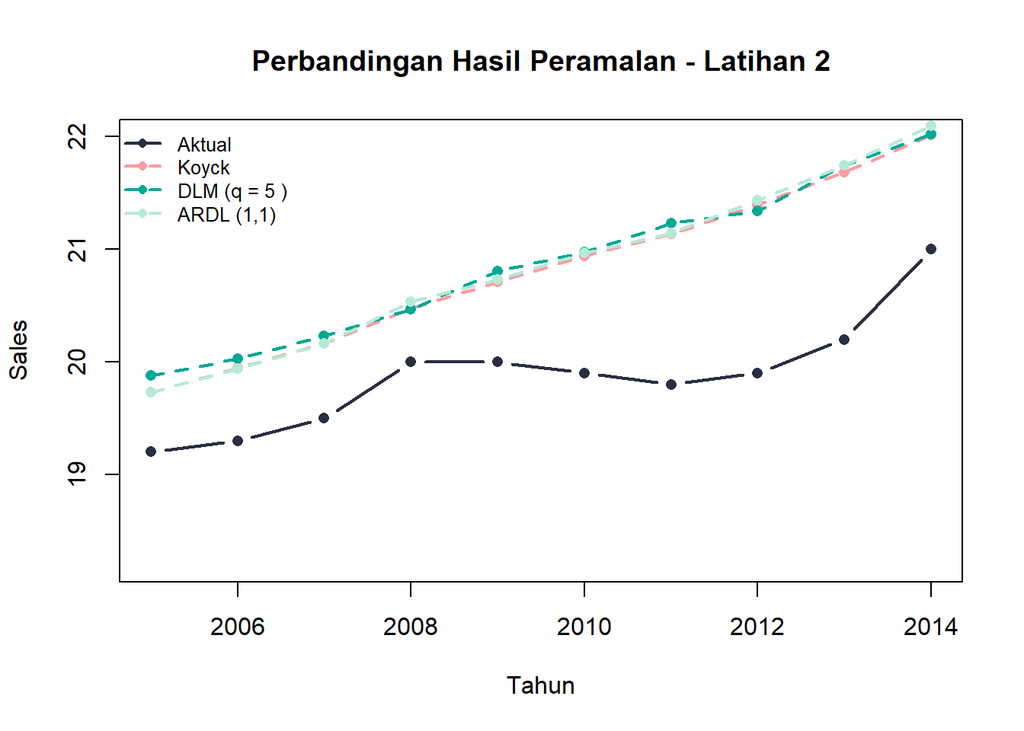

```r
# Atur layout grafik
par(mfrow = c(1,1))

# Plot data aktual (Test Data)
plot(test2$Year, test2$Sales, type = "b", col = "#2B2D42", lwd = 2, pch = 16,
     ylim = c(min(test2$Sales) - 1, max(test2$Sales) + 1),
     xlab = "Tahun", ylab = "Sales", main = "Perbandingan Hasil Peramalan - Latihan 2")

# Tambahkan garis hasil ramalan tiap model dengan warna pastel
points(test2$Year, fore.koyck2$forecasts, col = "#FF9AA2", pch = 16)
lines(test2$Year, fore.koyck2$forecasts, col = "#FF9AA2", lty = 2, lwd = 2)

points(test2$Year, fore.dlm2$forecasts, col = "#00A896", pch = 16)
lines(test2$Year, fore.dlm2$forecasts, col = "#00A896", lty = 2, lwd = 2)

points(test2$Year, fore.ardl2$forecasts, col = "#B5EAD7", pch = 16)
lines(test2$Year, fore.ardl2$forecasts, col = "#B5EAD7", lty = 2, lwd = 2)

# Legenda
legend("topleft",
       c("Aktual", "Koyck", paste("DLM (q =", q_best2, ")"), "ARDL (1,1)"),
       lty = c(1, 2, 2, 2), col = c("#2B2D42", "#FF9AA2", "#00A896", "#B5EAD7"),
       pch = 16, cex = 0.8, lwd = 2, bty = "n")
```

Berdasarkan evaluasi nilai kesalahan peramalan pada Latihan 2, Model Koyck terbukti menjadi model terbaik karena menghasilkan nilai MAPE paling rendah yaitu sebesar 0.0471 (atau sekitar 4.71%), diikuti oleh model ARDL (1,1) sebesar 0.0485 (4.85%) dan model DLM dengan q = 5 sebesar 0.0498 (4.98%). Secara visual, ketiga model menunjukkan pergerakan tren naik yang serupa dan berada sedikit di atas nilai aktual, tetapi Model Koyck secara keseluruhan memiliki tingkat akurasi yang paling tinggi sehingga sangat direkomendasikan untuk memprediksi tingkat penjualan (Sales) berbasis variabel pengeluaran iklan (Advertising).